# Exploration of Red Wine data by Prayag

Let’s start off by loading relevant packages and libraries.

Let’s read the csv file into a dataframe to start exploring and get the first impression of the data.

```
##  [1] "X"                    "fixed.acidity"        "volatile.acidity"
##  [4] "citric.acid"          "residual.sugar"       "chlorides"
##  [7] "free.sulfur.dioxide"  "total.sulfur.dioxide" "density"
## [10] "pH"                   "sulphates"            "alcohol"
## [13] "quality"
```

The first column looks like the index column which we do not need. Let’s get rid of it.

# Univariate Plots Section

Let’s get some initial feel for the data.

```
##  [1] "fixed.acidity"        "volatile.acidity"     "citric.acid"
##  [4] "residual.sugar"       "chlorides"            "free.sulfur.dioxide"
##  [7] "total.sulfur.dioxide" "density"              "pH"
## [10] "sulphates"            "alcohol"              "quality"
```

```
## 'data.frame':    1599 obs. of  12 variables:
##  $ fixed.acidity       : num  7.4 7.8 7.8 11.2 7.4 7.4 7.9 7.3 7.8 7.5 ...
##  $ volatile.acidity    : num  0.7 0.88 0.76 0.28 0.7 0.66 0.6 0.65 0.58 0.5 ...
##  $ citric.acid         : num  0 0 0.04 0.56 0 0 0.06 0 0.02 0.36 ...
##  $ residual.sugar      : num  1.9 2.6 2.3 1.9 1.9 1.8 1.6 1.2 2 6.1 ...
##  $ chlorides           : num  0.076 0.098 0.092 0.075 0.076 0.075 0.069 0.065 0.073 0.071 ...
##  $ free.sulfur.dioxide : num  11 25 15 17 11 13 15 15 9 17 ...
##  $ total.sulfur.dioxide: num  34 67 54 60 34 40 59 21 18 102 ...
##  $ density             : num  0.998 0.997 0.997 0.998 0.998 ...
##  $ pH                  : num  3.51 3.2 3.26 3.16 3.51 3.51 3.3 3.39 3.36 3.35 ...
##  $ sulphates           : num  0.56 0.68 0.65 0.58 0.56 0.56 0.46 0.47 0.57 0.8 ...
##  $ alcohol             : num  9.4 9.8 9.8 9.8 9.4 9.4 9.4 10 9.5 10.5 ...
##  $ quality             : int  5 5 5 6 5 5 5 7 7 5 ...
```

```
##  fixed.acidity   volatile.acidity  citric.acid    residual.sugar
##  Min.   : 4.60   Min.   :0.1200   Min.   :0.000   Min.   : 0.900
##  1st Qu.: 7.10   1st Qu.:0.3900   1st Qu.:0.090   1st Qu.: 1.900
##  Median : 7.90   Median :0.5200   Median :0.260   Median : 2.200
##  Mean   : 8.32   Mean   :0.5278   Mean   :0.271   Mean   : 2.539
##  3rd Qu.: 9.20   3rd Qu.:0.6400   3rd Qu.:0.420   3rd Qu.: 2.600
##  Max.   :15.90   Max.   :1.5800   Max.   :1.000   Max.   :15.500
##    chlorides       free.sulfur.dioxide total.sulfur.dioxide
##  Min.   :0.01200   Min.   : 1.00       Min.   :  6.00
##  1st Qu.:0.07000   1st Qu.: 7.00       1st Qu.: 22.00
##  Median :0.07900   Median :14.00       Median : 38.00
##  Mean   :0.08747   Mean   :15.87       Mean   : 46.47
##  3rd Qu.:0.09000   3rd Qu.:21.00       3rd Qu.: 62.00
##  Max.   :0.61100   Max.   :72.00       Max.   :289.00
##     density             pH          sulphates         alcohol
##  Min.   :0.9901   Min.   :2.740   Min.   :0.3300   Min.   : 8.40
##  1st Qu.:0.9956   1st Qu.:3.210   1st Qu.:0.5500   1st Qu.: 9.50
##  Median :0.9968   Median :3.310   Median :0.6200   Median :10.20
##  Mean   :0.9967   Mean   :3.311   Mean   :0.6581   Mean   :10.42
##  3rd Qu.:0.9978   3rd Qu.:3.400   3rd Qu.:0.7300   3rd Qu.:11.10
##  Max.   :1.0037   Max.   :4.010   Max.   :2.0000   Max.   :14.90
##     quality
##  Min.   :3.000
##  1st Qu.:5.000
##  Median :6.000
##  Mean   :5.636
##  3rd Qu.:6.000
##  Max.   :8.000
```

Looking at the data and summary, main variable of interest is the quality. How do different variable affect the quality of wine?

Minimum quality is 3 and maximum is 8 for red wines. The 1st quantile and the 3rd quantile is 5 and 6 respectively, suggesting that most of the quality ratings are concentrated between these two values. This is more or less also evident with mean of 5.636 and median value of 6. Let’s plot quality histogram to get a first impression of win quality across the spectrum.

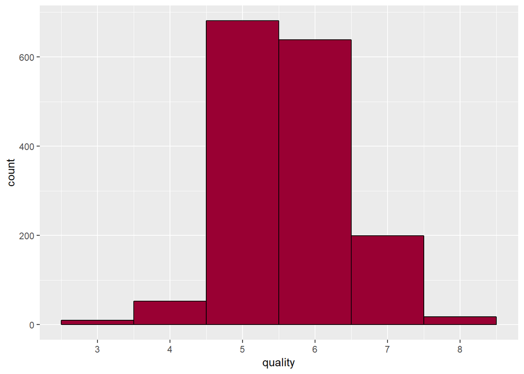

The histgram is almost normally distributed with a slight right skew. Most of the quality ratings are cummulated on 5 and 6. About 200 ratings on 7. However, very few wines have a quality rating of 3 as well as 8. Seems like the expert opinions are in the mid-ranges for most of the wines in our dataset.

Let’s plot distributions of all the variables

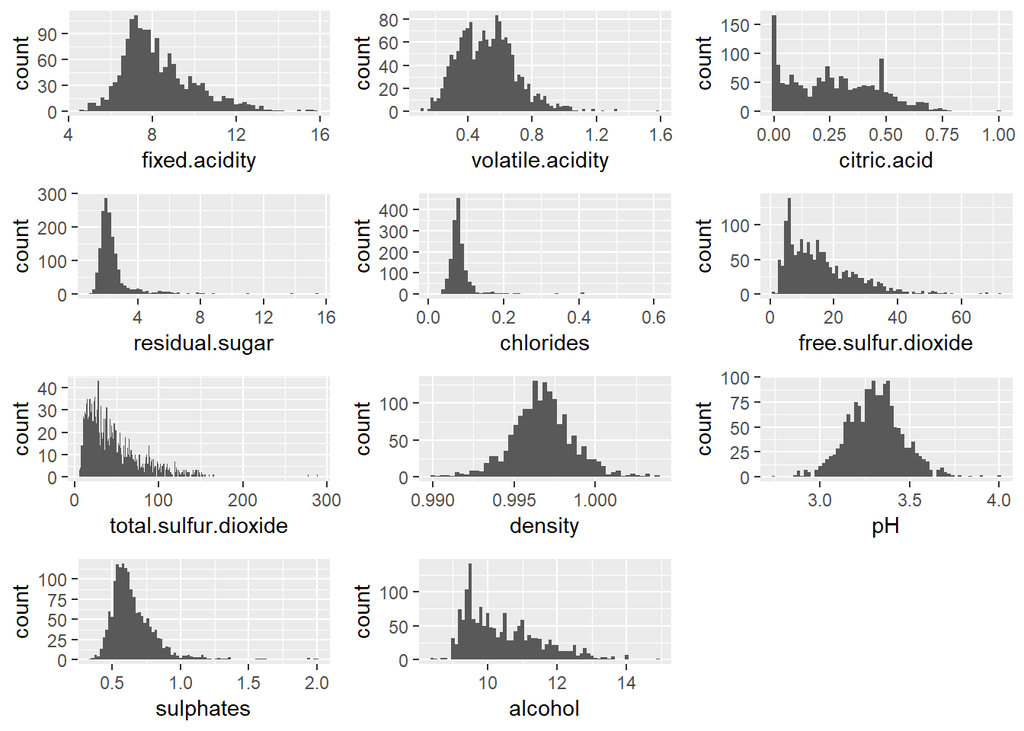

Looking at histograms of each variables, many variables have skewed distribution. However, it is also evident that this is because of the outliers being present. Let’s eliminate such outlier by not considering 1% of the edge data, as the summary suggests that most of the concentration of the data is around 3rd quantile.

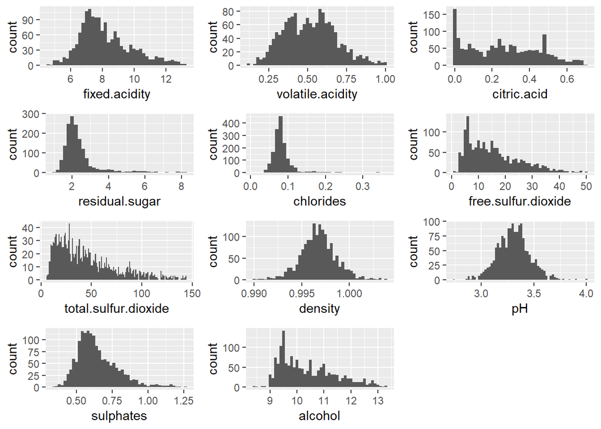

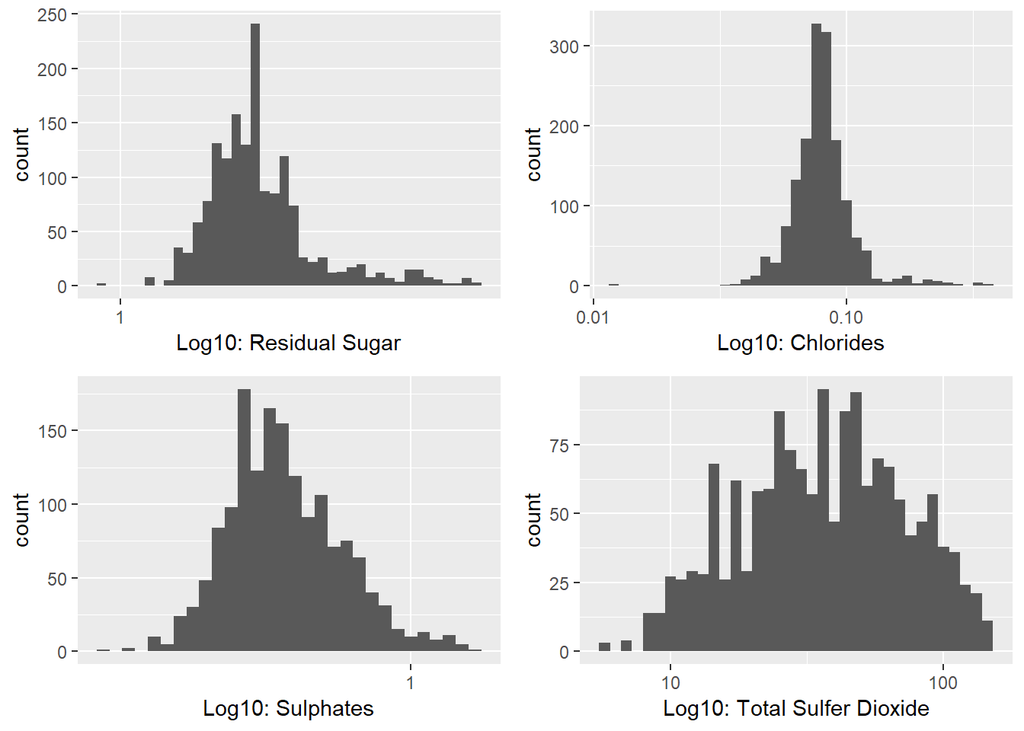

Applying log10 scale to residual sugar, chlorides, sulphates and sulfer dioxide the distribution looks more normal now.

# Univariate Analysis

### The structure of the dataset

There are total of 1599 observations with 12 variables in the dataset. None of the observations have missing or incomplete data.

### The main feature(s) of interest in the dataset

The main feature of interest in the dataset is, of course, the quality. How does the quality fare with all the variables? Can we predict the quality based upon some of these chemical properties when the actual rating is given by “Wine Experts” based on their individual sensory response! (most likey not!)

### Other features in the dataset that will help support investigation into the feature(s) of interest

Almost all the variables are of interest at this stage as we do not know how they are correlated. But looking at some of the variables it is evident that they are not independent. variables like citric acid and other acidity related variables are obviously related to one another.

### Unusual distributions and additional operations

`residual sugar`, `sulphates`, `chlorides` and `total sulfur dioxide` did not have normal distribution. However, changing them to log scale gave a better idea about their distribution.

# Bivariate Plots Section

Let’s first convert the quality variable into ordered factor for better understanding while exploring the relationships with other variables.

First of all, we will take a look at the relationships between all the variables and distributions.

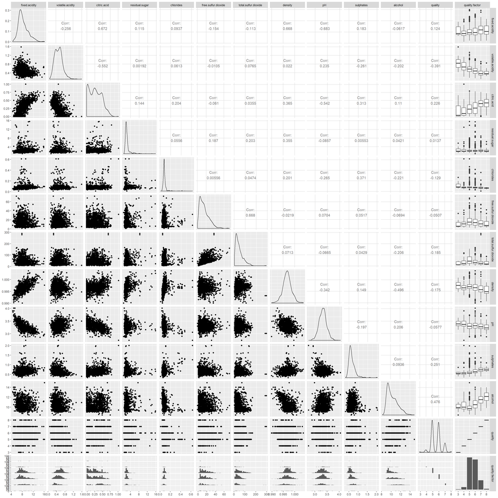

Now we have an overview of all the distributions, to have more clarity let’s plot the correlation plot for sake of simplicity.

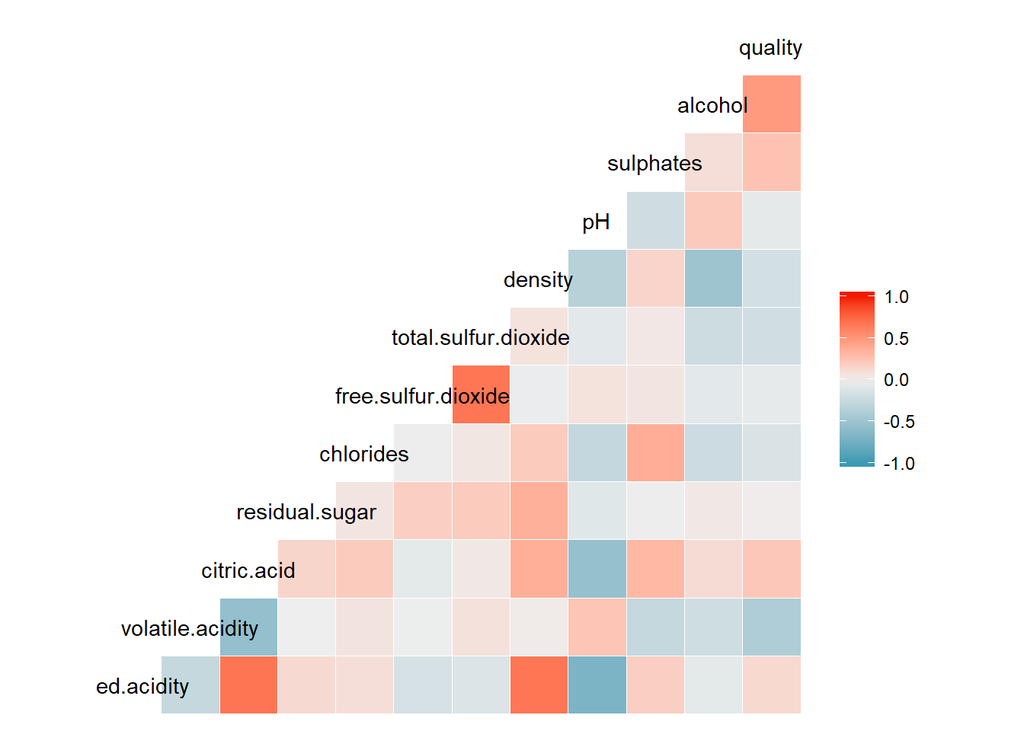

Upon first visual inspection it appears that many variables have visible correlations. In the following section we will explore some of these relations both statistically as well as graphically.

To begin with, we explore how does each variable impact the quality.

```
## wine$quality: 3
##    Min. 1st Qu.  Median    Mean 3rd Qu.    Max.
##   6.700   7.150   7.500   8.360   9.875  11.600
## --------------------------------------------------------
## wine$quality: 4
##    Min. 1st Qu.  Median    Mean 3rd Qu.    Max.
##   4.600   6.800   7.500   7.779   8.400  12.500
## --------------------------------------------------------
## wine$quality: 5
##    Min. 1st Qu.  Median    Mean 3rd Qu.    Max.
##   5.000   7.100   7.800   8.167   8.900  15.900
## --------------------------------------------------------
## wine$quality: 6
##    Min. 1st Qu.  Median    Mean 3rd Qu.    Max.
##   4.700   7.000   7.900   8.347   9.400  14.300
## --------------------------------------------------------
## wine$quality: 7
##    Min. 1st Qu.  Median    Mean 3rd Qu.    Max.
##   4.900   7.400   8.800   8.872  10.100  15.600
## --------------------------------------------------------
## wine$quality: 8
##    Min. 1st Qu.  Median    Mean 3rd Qu.    Max.
##   5.000   7.250   8.250   8.567  10.225  12.600
```

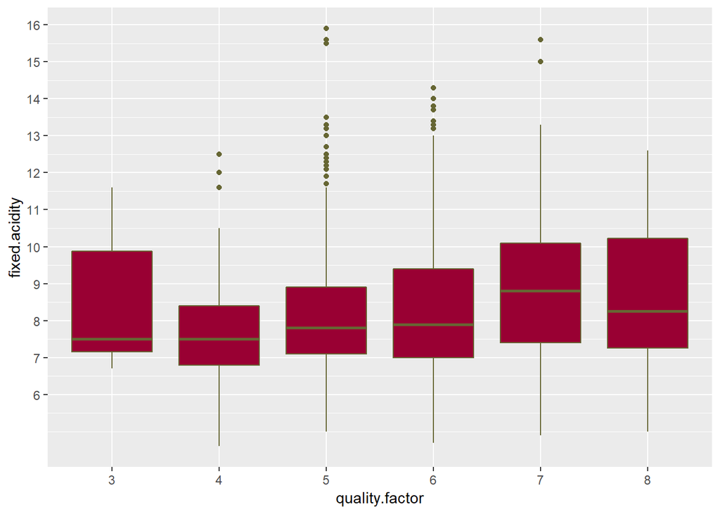

Looking at the median values for each quality with boxplots, there is a very little correlation. This we can confirm by running a correlation test

```
##
##  Pearson's product-moment correlation
##
## data:  wine$fixed.acidity and wine$quality
## t = 4.996, df = 1597, p-value = 6.496e-07
## alternative hypothesis: true correlation is not equal to 0
## 95 percent confidence interval:
##  0.07548957 0.17202667
## sample estimates:
##       cor
## 0.1240516
```

There is no substantial correlation indeed!

```
## wine$quality: 3
##    Min. 1st Qu.  Median    Mean 3rd Qu.    Max.
##  0.4400  0.6475  0.8450  0.8845  1.0100  1.5800
## --------------------------------------------------------
## wine$quality: 4
##    Min. 1st Qu.  Median    Mean 3rd Qu.    Max.
##   0.230   0.530   0.670   0.694   0.870   1.130
## --------------------------------------------------------
## wine$quality: 5
##    Min. 1st Qu.  Median    Mean 3rd Qu.    Max.
##   0.180   0.460   0.580   0.577   0.670   1.330
## --------------------------------------------------------
## wine$quality: 6
##    Min. 1st Qu.  Median    Mean 3rd Qu.    Max.
##  0.1600  0.3800  0.4900  0.4975  0.6000  1.0400
## --------------------------------------------------------
## wine$quality: 7
##    Min. 1st Qu.  Median    Mean 3rd Qu.    Max.
##  0.1200  0.3000  0.3700  0.4039  0.4850  0.9150
## --------------------------------------------------------
## wine$quality: 8
##    Min. 1st Qu.  Median    Mean 3rd Qu.    Max.
##  0.2600  0.3350  0.3700  0.4233  0.4725  0.8500
```

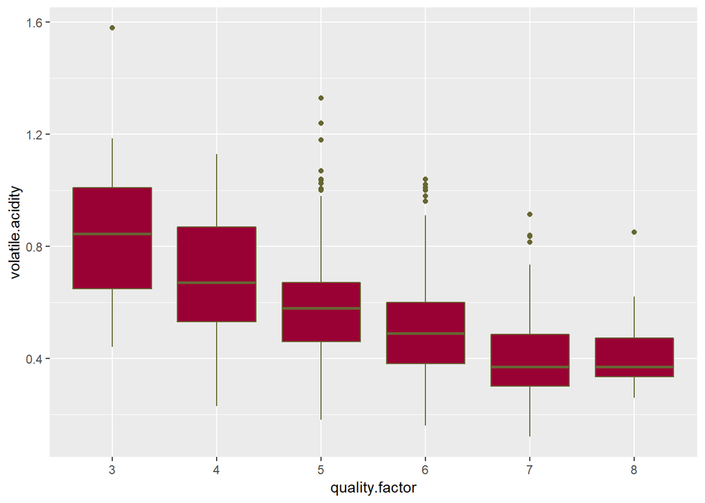

The plot suggests a very strong correlation. Wines with better quality seems to have lower volatile acidity. Let’s confirm that by correlation test.

```
##
##  Pearson's product-moment correlation
##
## data:  wine$volatile.acidity and wine$quality
## t = -16.954, df = 1597, p-value < 2.2e-16
## alternative hypothesis: true correlation is not equal to 0
## 95 percent confidence interval:
##  -0.4313210 -0.3482032
## sample estimates:
##        cor
## -0.3905578
```

The -0.3905 of correlation coefficient suggests a weak negative correlation.

```
## wine$quality: 3
##    Min. 1st Qu.  Median    Mean 3rd Qu.    Max.
##  0.0000  0.0050  0.0350  0.1710  0.3275  0.6600
## --------------------------------------------------------
## wine$quality: 4
##    Min. 1st Qu.  Median    Mean 3rd Qu.    Max.
##  0.0000  0.0300  0.0900  0.1742  0.2700  1.0000
## --------------------------------------------------------
## wine$quality: 5
##    Min. 1st Qu.  Median    Mean 3rd Qu.    Max.
##  0.0000  0.0900  0.2300  0.2437  0.3600  0.7900
## --------------------------------------------------------
## wine$quality: 6
##    Min. 1st Qu.  Median    Mean 3rd Qu.    Max.
##  0.0000  0.0900  0.2600  0.2738  0.4300  0.7800
## --------------------------------------------------------
## wine$quality: 7
##    Min. 1st Qu.  Median    Mean 3rd Qu.    Max.
##  0.0000  0.3050  0.4000  0.3752  0.4900  0.7600
## --------------------------------------------------------
## wine$quality: 8
##    Min. 1st Qu.  Median    Mean 3rd Qu.    Max.
##  0.0300  0.3025  0.4200  0.3911  0.5300  0.7200
```

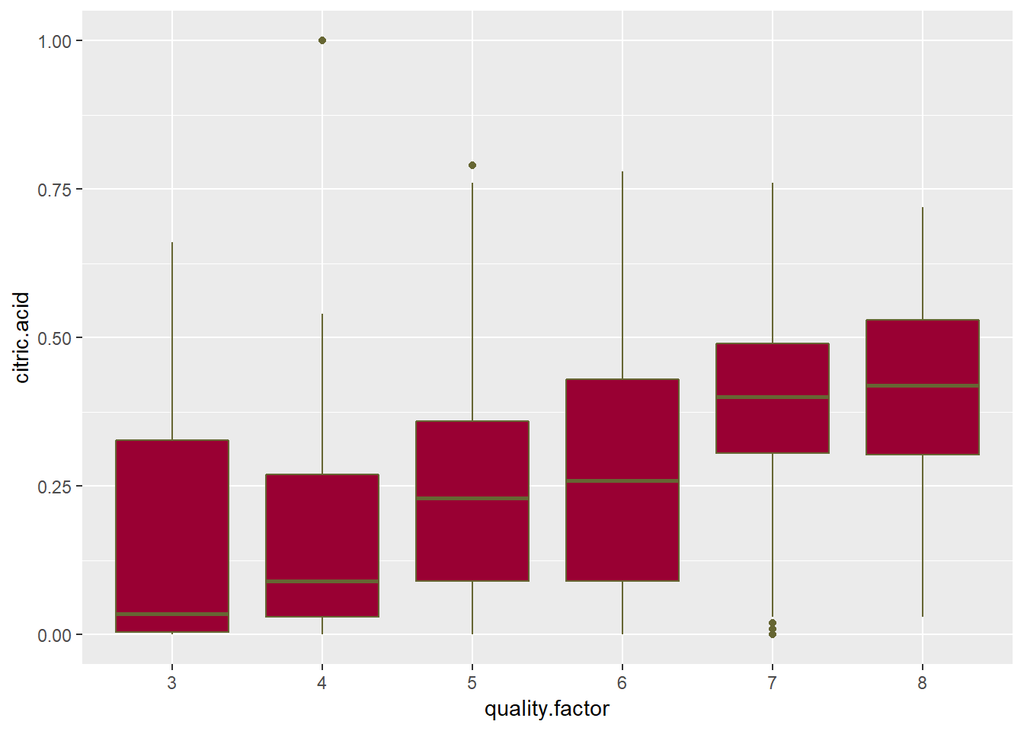

```
##
##  Pearson's product-moment correlation
##
## data:  wine$citric.acid and wine$quality
## t = 9.2875, df = 1597, p-value < 2.2e-16
## alternative hypothesis: true correlation is not equal to 0
## 95 percent confidence interval:
##  0.1793415 0.2723711
## sample estimates:
##       cor
## 0.2263725
```

It looks like the higher concentrations of citric acid tends to get a higher quality rating. But, looking at the positive yet weak correlation coefficient of 0.2263, we get some mixed signal. Let’s further explore and come back to this one at later point.

```
## wine$quality: 3
##    Min. 1st Qu.  Median    Mean 3rd Qu.    Max.
##   1.200   1.875   2.100   2.635   3.100   5.700
## --------------------------------------------------------
## wine$quality: 4
##    Min. 1st Qu.  Median    Mean 3rd Qu.    Max.
##   1.300   1.900   2.100   2.694   2.800  12.900
## --------------------------------------------------------
## wine$quality: 5
##    Min. 1st Qu.  Median    Mean 3rd Qu.    Max.
##   1.200   1.900   2.200   2.529   2.600  15.500
## --------------------------------------------------------
## wine$quality: 6
##    Min. 1st Qu.  Median    Mean 3rd Qu.    Max.
##   0.900   1.900   2.200   2.477   2.500  15.400
## --------------------------------------------------------
## wine$quality: 7
##    Min. 1st Qu.  Median    Mean 3rd Qu.    Max.
##   1.200   2.000   2.300   2.721   2.750   8.900
## --------------------------------------------------------
## wine$quality: 8
##    Min. 1st Qu.  Median    Mean 3rd Qu.    Max.
##   1.400   1.800   2.100   2.578   2.600   6.400
```

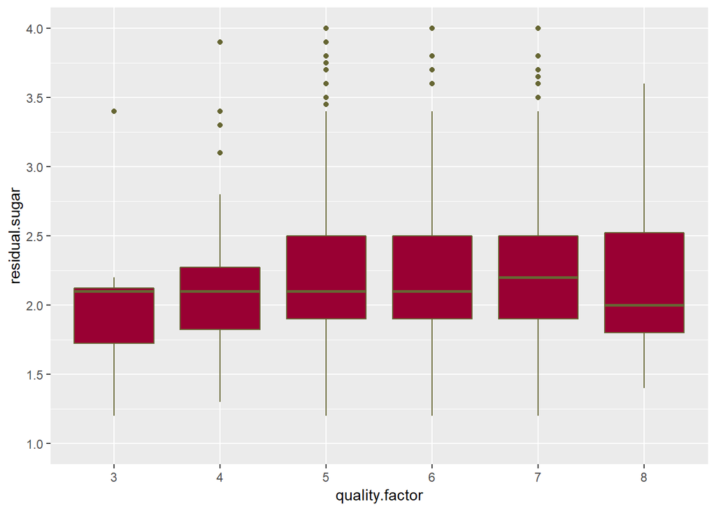

```
##
##  Pearson's product-moment correlation
##
## data:  wine$residual.sugar and wine$quality
## t = 0.5488, df = 1597, p-value = 0.5832
## alternative hypothesis: true correlation is not equal to 0
## 95 percent confidence interval:
##  -0.03531327  0.06271056
## sample estimates:
##        cor
## 0.01373164
```

```
## wine$quality: 3
##    Min. 1st Qu.  Median    Mean 3rd Qu.    Max.
##  0.0610  0.0790  0.0905  0.1225  0.1430  0.2670
## --------------------------------------------------------
## wine$quality: 4
##    Min. 1st Qu.  Median    Mean 3rd Qu.    Max.
## 0.04500 0.06700 0.08000 0.09068 0.08900 0.61000
## --------------------------------------------------------
## wine$quality: 5
##    Min. 1st Qu.  Median    Mean 3rd Qu.    Max.
## 0.03900 0.07400 0.08100 0.09274 0.09400 0.61100
## --------------------------------------------------------
## wine$quality: 6
##    Min. 1st Qu.  Median    Mean 3rd Qu.    Max.
## 0.03400 0.06825 0.07800 0.08496 0.08800 0.41500
## --------------------------------------------------------
## wine$quality: 7
##    Min. 1st Qu.  Median    Mean 3rd Qu.    Max.
## 0.01200 0.06200 0.07300 0.07659 0.08700 0.35800
## --------------------------------------------------------
## wine$quality: 8
##    Min. 1st Qu.  Median    Mean 3rd Qu.    Max.
## 0.04400 0.06200 0.07050 0.06844 0.07550 0.08600
```

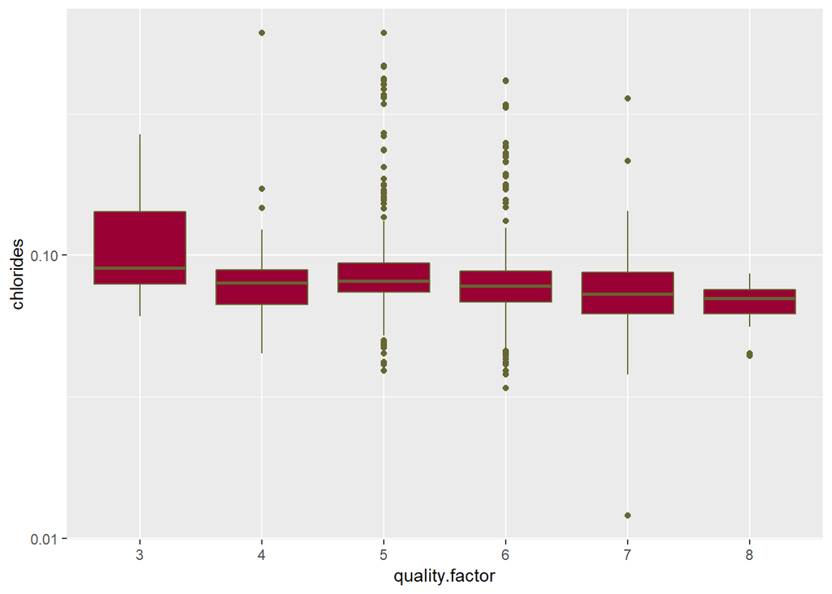

```
##
##  Pearson's product-moment correlation
##
## data:  wine$chlorides and wine$quality
## t = -5.1948, df = 1597, p-value = 2.313e-07
## alternative hypothesis: true correlation is not equal to 0
## 95 percent confidence interval:
##  -0.17681041 -0.08039344
## sample estimates:
##        cor
## -0.1289066
```

Chlorides are also not really an impacting factor. But it is worth noting that bad quality wines have relatively higher concentrations of chlorides.

```
## wine$quality: 3
##    Min. 1st Qu.  Median    Mean 3rd Qu.    Max.
##     3.0     5.0     6.0    11.0    14.5    34.0
## --------------------------------------------------------
## wine$quality: 4
##    Min. 1st Qu.  Median    Mean 3rd Qu.    Max.
##    3.00    6.00   11.00   12.26   15.00   41.00
## --------------------------------------------------------
## wine$quality: 5
##    Min. 1st Qu.  Median    Mean 3rd Qu.    Max.
##    3.00    9.00   15.00   16.98   23.00   68.00
## --------------------------------------------------------
## wine$quality: 6
##    Min. 1st Qu.  Median    Mean 3rd Qu.    Max.
##    1.00    8.00   14.00   15.71   21.00   72.00
## --------------------------------------------------------
## wine$quality: 7
##    Min. 1st Qu.  Median    Mean 3rd Qu.    Max.
##    3.00    6.00   11.00   14.05   18.00   54.00
## --------------------------------------------------------
## wine$quality: 8
##    Min. 1st Qu.  Median    Mean 3rd Qu.    Max.
##    3.00    6.00    7.50   13.28   16.50   42.00
```

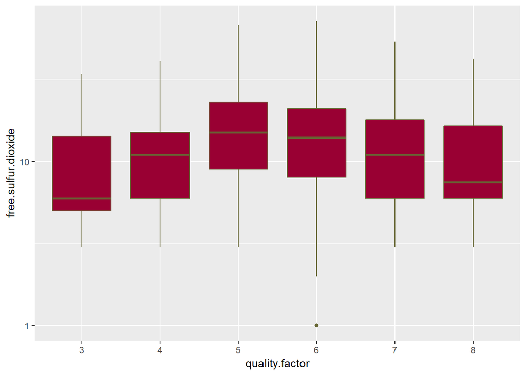

```
##
##  Pearson's product-moment correlation
##
## data:  wine$free.sulfur.dioxide and wine$quality
## t = -2.0269, df = 1597, p-value = 0.04283
## alternative hypothesis: true correlation is not equal to 0
## 95 percent confidence interval:
##  -0.099430290 -0.001638987
## sample estimates:
##         cor
## -0.05065606
```

```
## wine$quality: 3
##    Min. 1st Qu.  Median    Mean 3rd Qu.    Max.
##     9.0    12.5    15.0    24.9    42.5    49.0
## --------------------------------------------------------
## wine$quality: 4
##    Min. 1st Qu.  Median    Mean 3rd Qu.    Max.
##    7.00   14.00   26.00   36.25   49.00  119.00
## --------------------------------------------------------
## wine$quality: 5
##    Min. 1st Qu.  Median    Mean 3rd Qu.    Max.
##    6.00   26.00   47.00   56.51   84.00  155.00
## --------------------------------------------------------
## wine$quality: 6
##    Min. 1st Qu.  Median    Mean 3rd Qu.    Max.
##    6.00   23.00   35.00   40.87   54.00  165.00
## --------------------------------------------------------
## wine$quality: 7
##    Min. 1st Qu.  Median    Mean 3rd Qu.    Max.
##    7.00   17.50   27.00   35.02   43.00  289.00
## --------------------------------------------------------
## wine$quality: 8
##    Min. 1st Qu.  Median    Mean 3rd Qu.    Max.
##   12.00   16.00   21.50   33.44   43.00   88.00
```

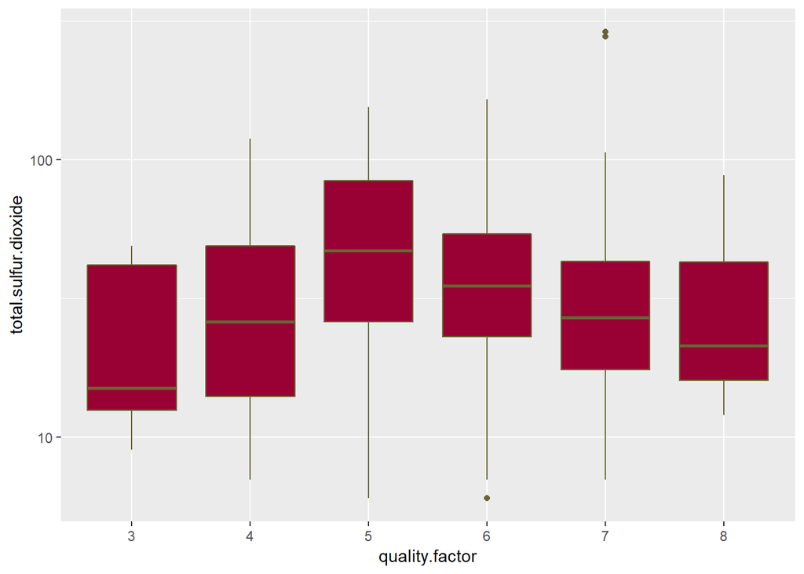

```
##
##  Pearson's product-moment correlation
##
## data:  wine$total.sulfur.dioxide and wine$quality
## t = -7.5271, df = 1597, p-value = 8.622e-14
## alternative hypothesis: true correlation is not equal to 0
## 95 percent confidence interval:
##  -0.2320162 -0.1373252
## sample estimates:
##        cor
## -0.1851003
```

Notice that free sulfur dioxide and total sulfur dioxide have similar plots. It is obvious that free sulfer dioxide is a subset of total sulfur dioxide. A quick look on the scatter plot should reveal that.

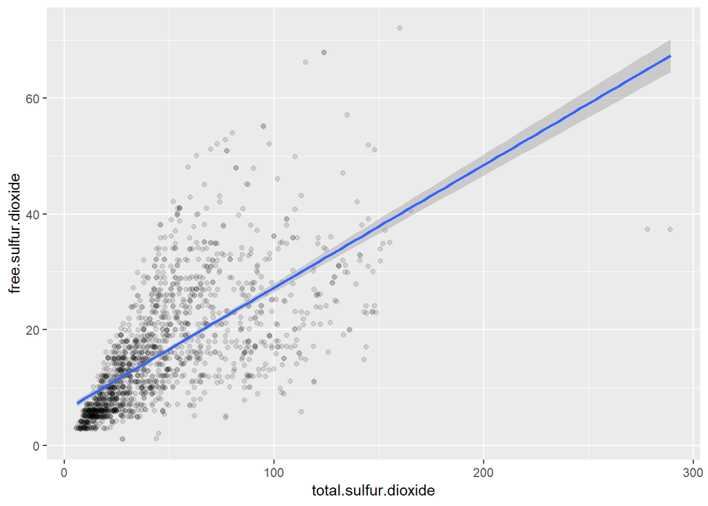

```
##
##  Pearson's product-moment correlation
##
## data:  wine$total.sulfur.dioxide and wine$free.sulfur.dioxide
## t = 35.84, df = 1597, p-value < 2.2e-16
## alternative hypothesis: true correlation is not equal to 0
## 95 percent confidence interval:
##  0.6395786 0.6939740
## sample estimates:
##       cor
## 0.6676665
```

A correlation coeeficient of 0.6677 justifies our suspicion.

```
## wine$quality: 3
##    Min. 1st Qu.  Median    Mean 3rd Qu.    Max.
##  0.9947  0.9961  0.9976  0.9975  0.9988  1.0008
## --------------------------------------------------------
## wine$quality: 4
##    Min. 1st Qu.  Median    Mean 3rd Qu.    Max.
##  0.9934  0.9957  0.9965  0.9965  0.9974  1.0010
## --------------------------------------------------------
## wine$quality: 5
##    Min. 1st Qu.  Median    Mean 3rd Qu.    Max.
##  0.9926  0.9962  0.9970  0.9971  0.9979  1.0031
## --------------------------------------------------------
## wine$quality: 6
##    Min. 1st Qu.  Median    Mean 3rd Qu.    Max.
##  0.9901  0.9954  0.9966  0.9966  0.9979  1.0037
## --------------------------------------------------------
## wine$quality: 7
##    Min. 1st Qu.  Median    Mean 3rd Qu.    Max.
##  0.9906  0.9948  0.9958  0.9961  0.9974  1.0032
## --------------------------------------------------------
## wine$quality: 8
##    Min. 1st Qu.  Median    Mean 3rd Qu.    Max.
##  0.9908  0.9942  0.9949  0.9952  0.9972  0.9988
```

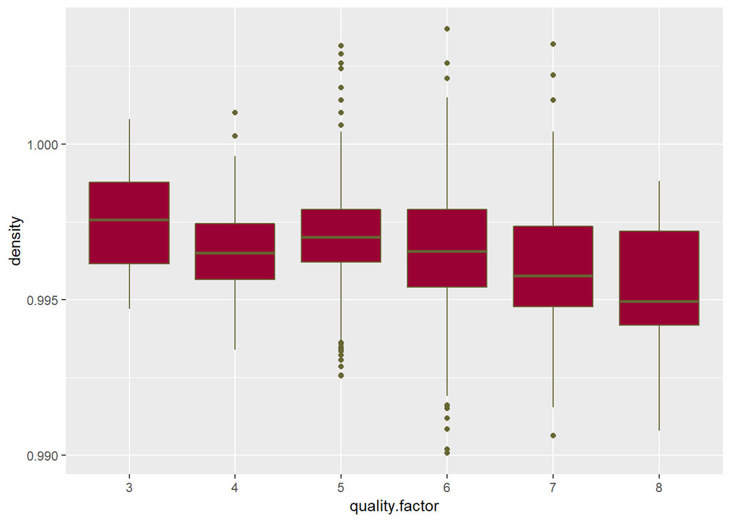

```
##
##  Pearson's product-moment correlation
##
## data:  wine$density and wine$quality
## t = -7.0997, df = 1597, p-value = 1.875e-12
## alternative hypothesis: true correlation is not equal to 0
## 95 percent confidence interval:
##  -0.2220365 -0.1269870
## sample estimates:
##        cor
## -0.1749192
```

Better quality wines have relatively lower density. This, we can see why upon exploring alcohol levels with respect to quality.

```
## wine$quality: 3
##    Min. 1st Qu.  Median    Mean 3rd Qu.    Max.
##   3.160   3.312   3.390   3.398   3.495   3.630
## --------------------------------------------------------
## wine$quality: 4
##    Min. 1st Qu.  Median    Mean 3rd Qu.    Max.
##   2.740   3.300   3.370   3.382   3.500   3.900
## --------------------------------------------------------
## wine$quality: 5
##    Min. 1st Qu.  Median    Mean 3rd Qu.    Max.
##   2.880   3.200   3.300   3.305   3.400   3.740
## --------------------------------------------------------
## wine$quality: 6
##    Min. 1st Qu.  Median    Mean 3rd Qu.    Max.
##   2.860   3.220   3.320   3.318   3.410   4.010
## --------------------------------------------------------
## wine$quality: 7
##    Min. 1st Qu.  Median    Mean 3rd Qu.    Max.
##   2.920   3.200   3.280   3.291   3.380   3.780
## --------------------------------------------------------
## wine$quality: 8
##    Min. 1st Qu.  Median    Mean 3rd Qu.    Max.
##   2.880   3.163   3.230   3.267   3.350   3.720
```

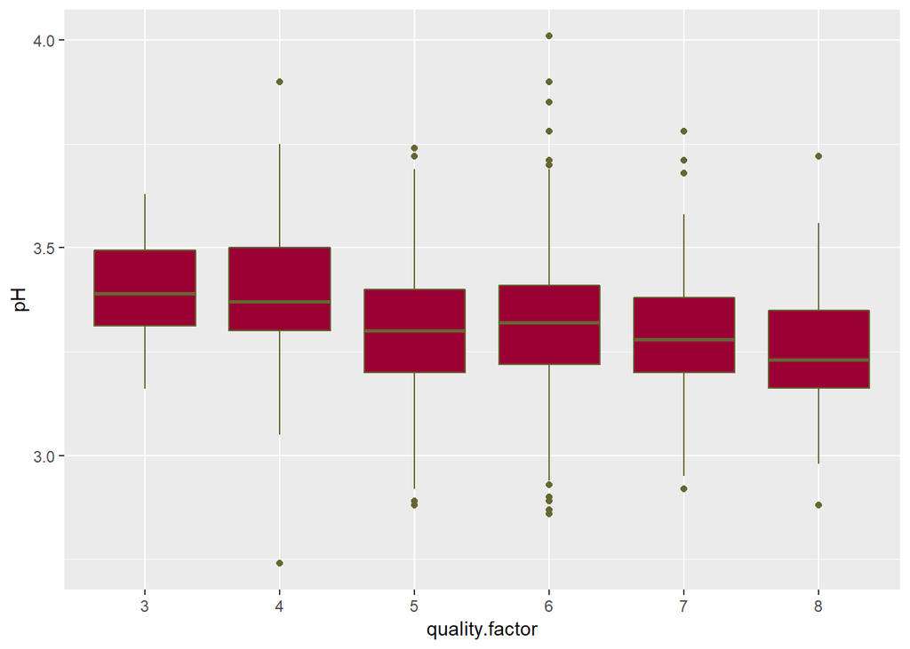

```
##
##  Pearson's product-moment correlation
##
## data:  wine$pH and wine$quality
## t = -2.3109, df = 1597, p-value = 0.02096
## alternative hypothesis: true correlation is not equal to 0
## 95 percent confidence interval:
##  -0.106451268 -0.008734972
## sample estimates:
##         cor
## -0.05773139
```

Better quality wines seems to have less pH levels.

```
## wine$quality: 3
##    Min. 1st Qu.  Median    Mean 3rd Qu.    Max.
##  0.4000  0.5125  0.5450  0.5700  0.6150  0.8600
## --------------------------------------------------------
## wine$quality: 4
##    Min. 1st Qu.  Median    Mean 3rd Qu.    Max.
##  0.3300  0.4900  0.5600  0.5964  0.6000  2.0000
## --------------------------------------------------------
## wine$quality: 5
##    Min. 1st Qu.  Median    Mean 3rd Qu.    Max.
##   0.370   0.530   0.580   0.621   0.660   1.980
## --------------------------------------------------------
## wine$quality: 6
##    Min. 1st Qu.  Median    Mean 3rd Qu.    Max.
##  0.4000  0.5800  0.6400  0.6753  0.7500  1.9500
## --------------------------------------------------------
## wine$quality: 7
##    Min. 1st Qu.  Median    Mean 3rd Qu.    Max.
##  0.3900  0.6500  0.7400  0.7413  0.8300  1.3600
## --------------------------------------------------------
## wine$quality: 8
##    Min. 1st Qu.  Median    Mean 3rd Qu.    Max.
##  0.6300  0.6900  0.7400  0.7678  0.8200  1.1000
```

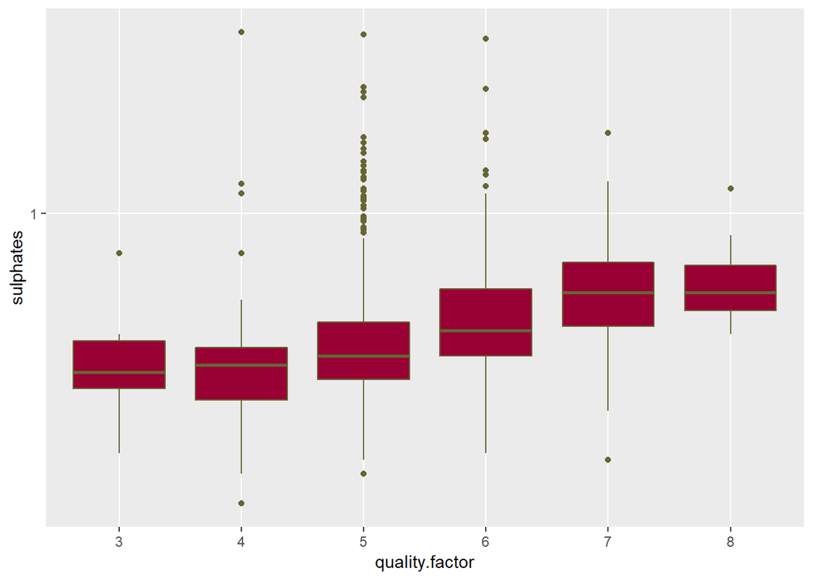

```
##
##  Pearson's product-moment correlation
##
## data:  wine$sulphates and wine$quality
## t = 10.38, df = 1597, p-value < 2.2e-16
## alternative hypothesis: true correlation is not equal to 0
## 95 percent confidence interval:
##  0.2049011 0.2967610
## sample estimates:
##       cor
## 0.2513971
```

```
## wine$quality: 3
##    Min. 1st Qu.  Median    Mean 3rd Qu.    Max.
##   8.400   9.725   9.925   9.955  10.575  11.000
## --------------------------------------------------------
## wine$quality: 4
##    Min. 1st Qu.  Median    Mean 3rd Qu.    Max.
##    9.00    9.60   10.00   10.27   11.00   13.10
## --------------------------------------------------------
## wine$quality: 5
##    Min. 1st Qu.  Median    Mean 3rd Qu.    Max.
##     8.5     9.4     9.7     9.9    10.2    14.9
## --------------------------------------------------------
## wine$quality: 6
##    Min. 1st Qu.  Median    Mean 3rd Qu.    Max.
##    8.40    9.80   10.50   10.63   11.30   14.00
## --------------------------------------------------------
## wine$quality: 7
##    Min. 1st Qu.  Median    Mean 3rd Qu.    Max.
##    9.20   10.80   11.50   11.47   12.10   14.00
## --------------------------------------------------------
## wine$quality: 8
##    Min. 1st Qu.  Median    Mean 3rd Qu.    Max.
##    9.80   11.32   12.15   12.09   12.88   14.00
```

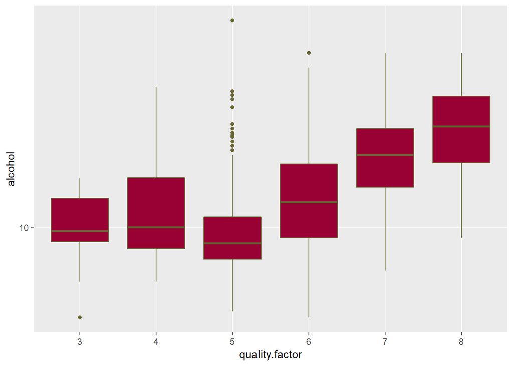

```
##
##  Pearson's product-moment correlation
##
## data:  wine$alcohol and wine$quality
## t = 21.639, df = 1597, p-value < 2.2e-16
## alternative hypothesis: true correlation is not equal to 0
## 95 percent confidence interval:
##  0.4373540 0.5132081
## sample estimates:
##       cor
## 0.4761663
```

Higher alcohol better quality!! Next time if you are wondering which red wine to bring to your friend’s dinner, pick one with higher alochol content!

Now, let’s look at some other interesting relationships.

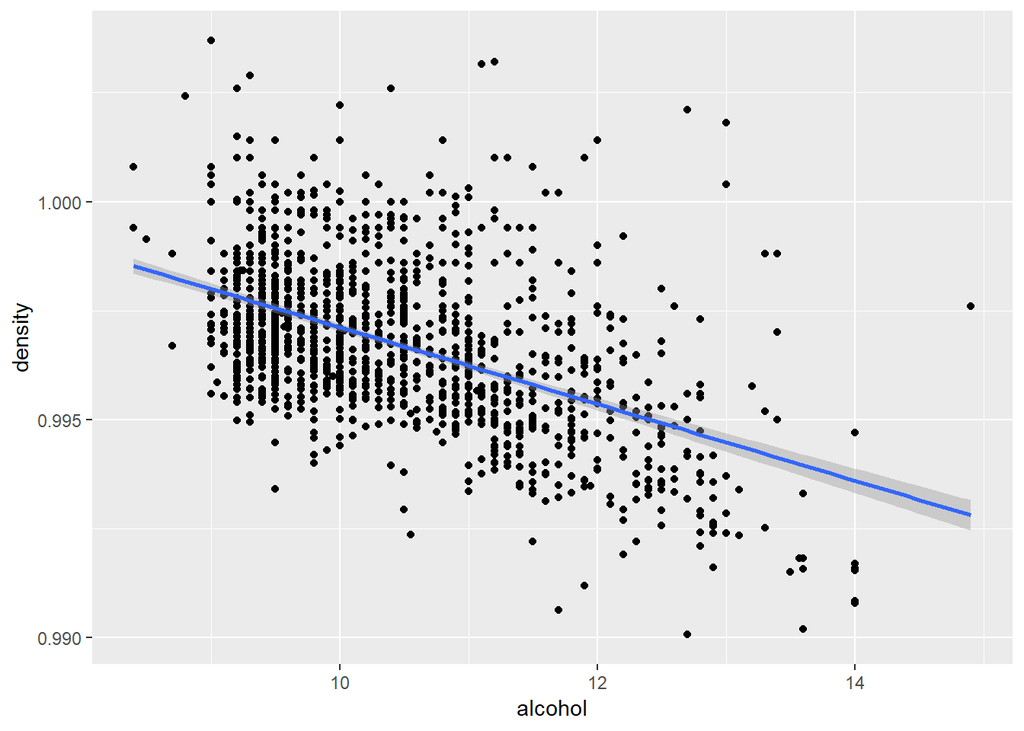

```
##
##  Pearson's product-moment correlation
##
## data:  wine$alcohol and wine$density
## t = -22.838, df = 1597, p-value < 2.2e-16
## alternative hypothesis: true correlation is not equal to 0
## 95 percent confidence interval:
##  -0.5322547 -0.4583061
## sample estimates:
##        cor
## -0.4961798
```

The density of wine have moderate negative correlation with density. Since, alcohol has less density than water, it is obvious that the density would decrease.

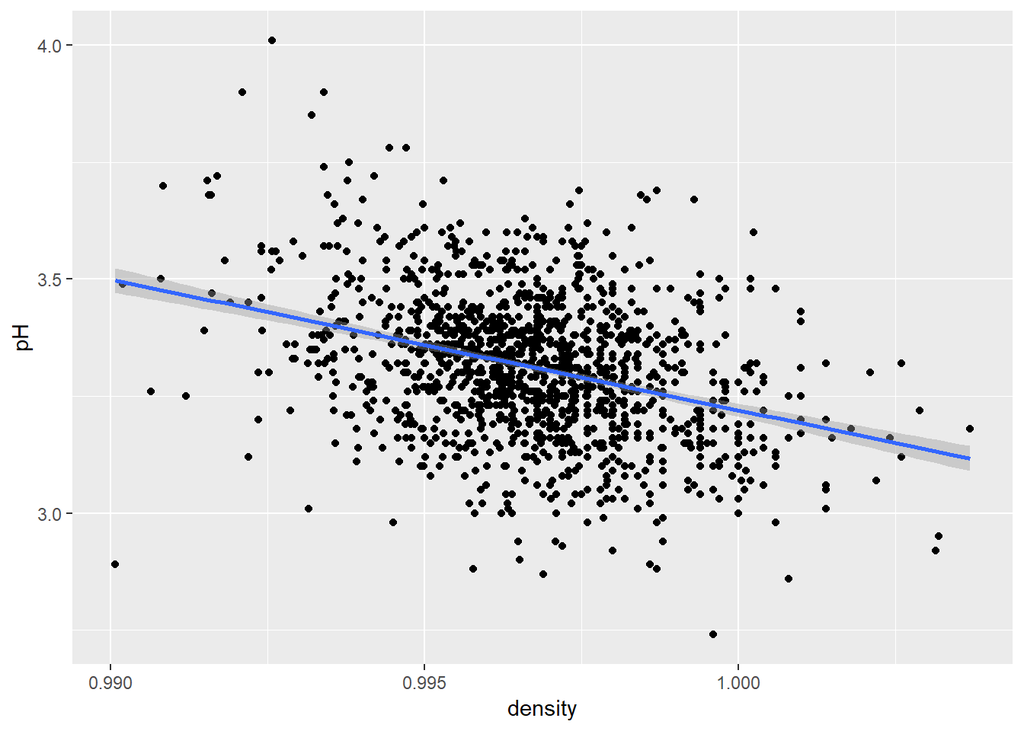

```
##
##  Pearson's product-moment correlation
##
## data:  wine$density and wine$pH
## t = -14.53, df = 1597, p-value < 2.2e-16
## alternative hypothesis: true correlation is not equal to 0
## 95 percent confidence interval:
##  -0.3842835 -0.2976642
## sample estimates:
##        cor
## -0.3416993
```

As density increases the pH level decreases.

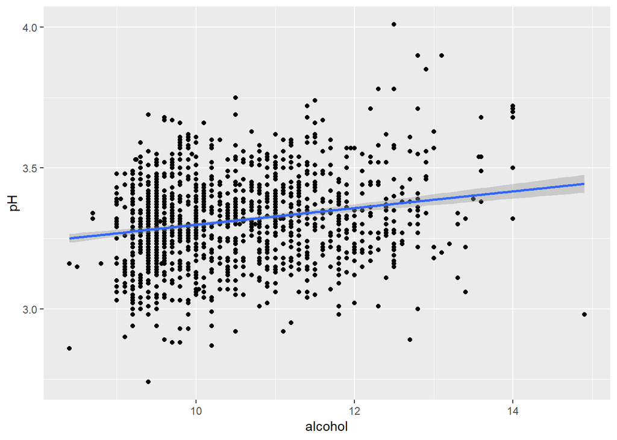

```
##
##  Pearson's product-moment correlation
##
## data:  wine$alcohol and wine$pH
## t = 8.397, df = 1597, p-value < 2.2e-16
## alternative hypothesis: true correlation is not equal to 0
## 95 percent confidence interval:
##  0.1582061 0.2521123
## sample estimates:
##       cor
## 0.2056325
```

However, alcohol and pH are positive yet weakly correlated.

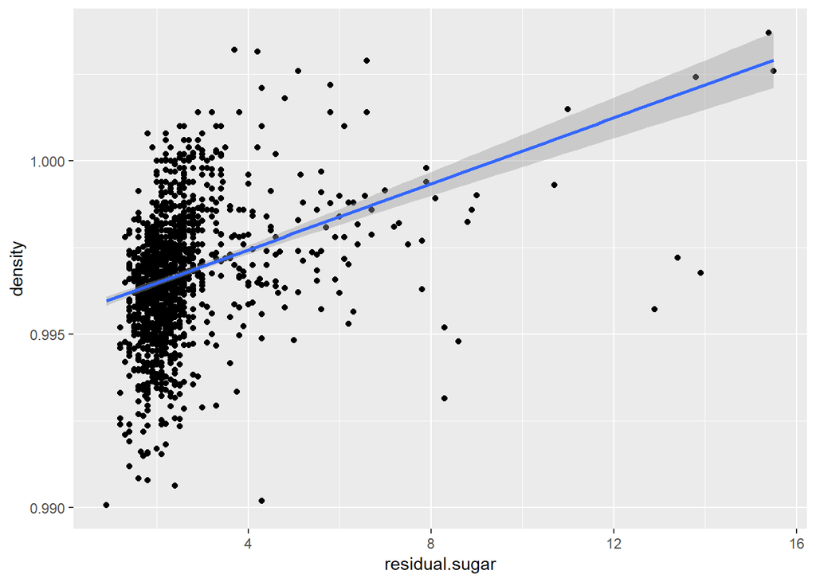

```
##
##  Pearson's product-moment correlation
##
## data:  wine$residual.sugar and wine$density
## t = 15.189, df = 1597, p-value < 2.2e-16
## alternative hypothesis: true correlation is not equal to 0
## 95 percent confidence interval:
##  0.3116908 0.3973835
## sample estimates:
##       cor
## 0.3552834
```

Correlation coefficient of 0.3553 is positively weak.

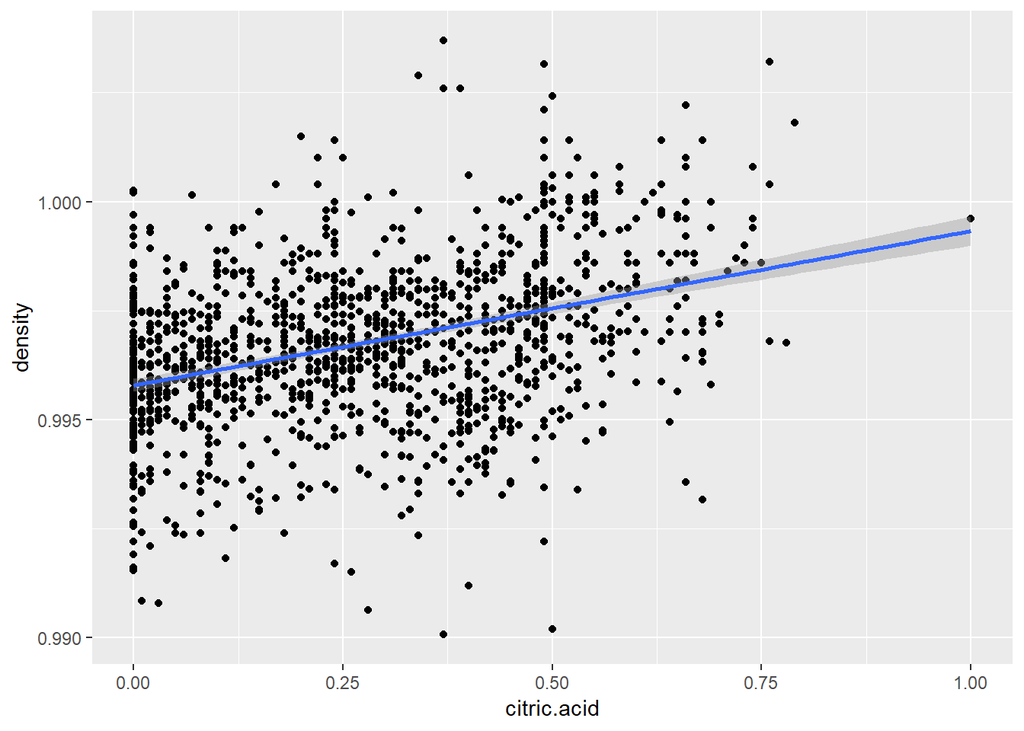

```
##
##  Pearson's product-moment correlation
##
## data:  wine$citric.acid and wine$density
## t = 15.665, df = 1597, p-value < 2.2e-16
## alternative hypothesis: true correlation is not equal to 0
## 95 percent confidence interval:
##  0.3216809 0.4066925
## sample estimates:
##       cor
## 0.3649472
```

There is a weak positive correlation between citric acid and density. The density increases with increase in citric acid. Also on the other hands many wines with 0.00 citric acid also have density upto 1.00. Meaning there are other variables impacting density as well which we explored earlier as well.

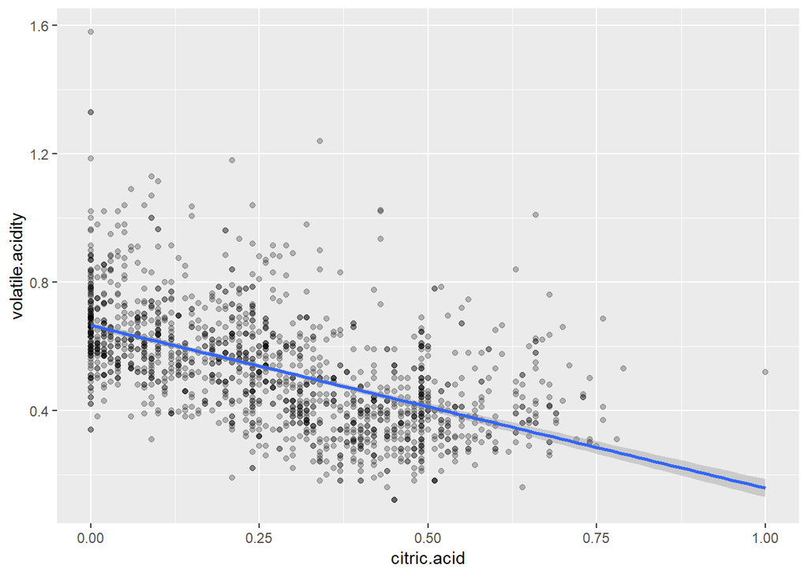

```
##
##  Pearson's product-moment correlation
##
## data:  wine$citric.acid and wine$volatile.acidity
## t = -26.489, df = 1597, p-value < 2.2e-16
## alternative hypothesis: true correlation is not equal to 0
## 95 percent confidence interval:
##  -0.5856550 -0.5174902
## sample estimates:
##        cor
## -0.5524957
```

There is a moderately strong negative correlation between volatile acidity with citric acid. It makes sense that acidity being measure of how acidic a component is. Volatile acidity decreases as the content of citric acid increases.

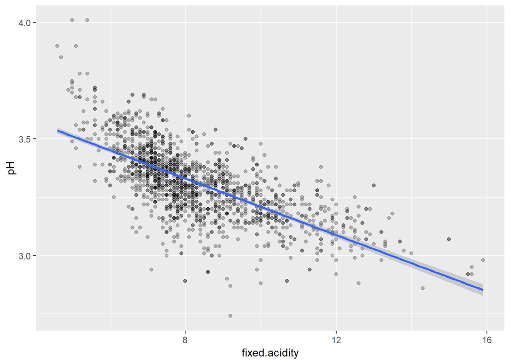

```
##
##  Pearson's product-moment correlation
##
## data:  wine$fixed.acidity and wine$pH
## t = -37.366, df = 1597, p-value < 2.2e-16
## alternative hypothesis: true correlation is not equal to 0
## 95 percent confidence interval:
##  -0.7082857 -0.6559174
## sample estimates:
##        cor
## -0.6829782
```

pH is a direct measure of acidic or basic nature of a liquid. It is obvious that increased fixed acidity would decrease the pH level and represent a strong negative correlation.

From above exploration, we found that alchol is the strongest correlating variable to higher quality ranking. Let’s try to fit a linear model to see how much of an impact it has on quality.

```
##
## Call:
## lm(formula = I(alcohol) ~ I(quality), data = wine)
##
## Residuals:
##     Min      1Q  Median      3Q     Max
## -2.2517 -0.6233 -0.2233  0.5483  4.8767
##
## Coefficients:
##             Estimate Std. Error t value Pr(>|t|)
## (Intercept)  6.88160    0.16532   41.62   <2e-16 ***
## I(quality)   0.62835    0.02904   21.64   <2e-16 ***
## ---
## Signif. codes:  0 '***' 0.001 '**' 0.01 '*' 0.05 '.' 0.1 ' ' 1
##
## Residual standard error: 0.9374 on 1597 degrees of freedom
## Multiple R-squared:  0.2267, Adjusted R-squared:  0.2263
## F-statistic: 468.3 on 1 and 1597 DF,  p-value: < 2.2e-16
```

From the coefficient of determination, R-squared, the alcohol has 22.67% of share in the prediction of quality of red wines. Despite many properties which can be measured and evaluate by scientific methods available in the data, the quality ratings were given by humans (based on sensory data) which are difficult to predict.

We will further investigate this with more variables and their impact in the next section.

# Bivariate Analysis

### Some of the relationships observed in this part of the investigation

- Better quality wines have lower volatile acidity and higher amounts of citric acids.
- Wines with lower densities tends to get higher quality ratings.
- More the alcohol better the wine, according to the experts!

### Interesting relationships between the other features (not the main feature(s) of interest)?

# Multivariate Plots Section

To start with, let’s create an additional variable called ratings in our dataframe.

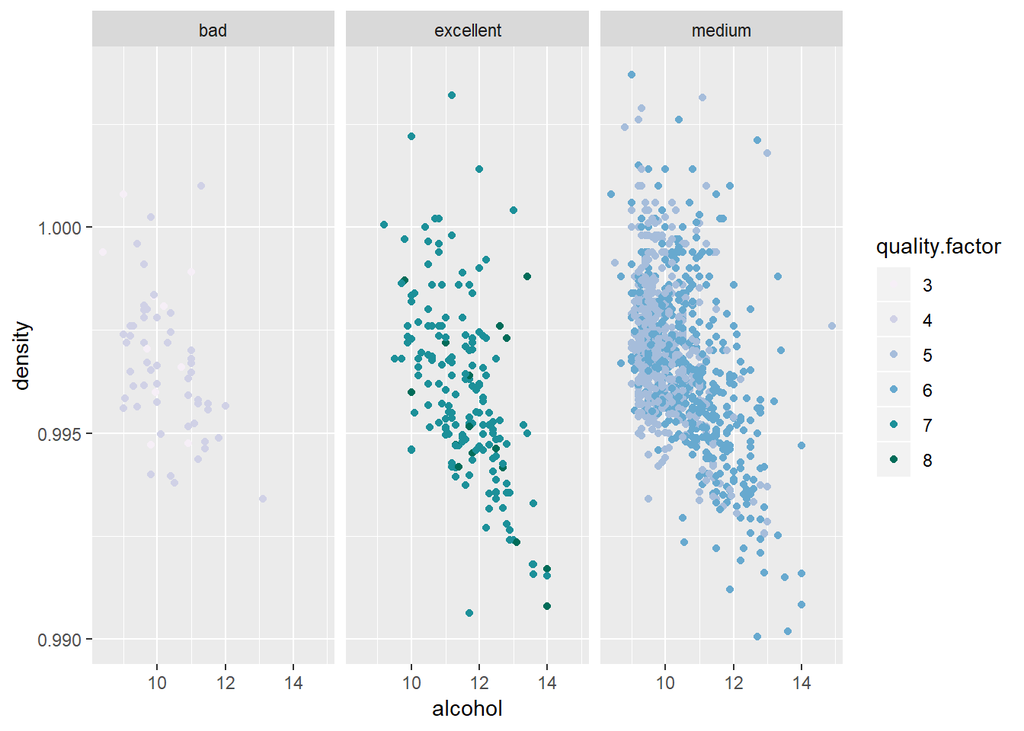

As we discussed in the previous section on how the density, alcohol levels interact with one another when it comes to percieved quality, we can see in the plot above. While medium quality wines have their fair share of higher alcohol content and density, the high quality wines have almost exclusively alcohol content 10 or more. Compared to medium quality wines, a huge chunk of those are belowe 10 alcohol level.

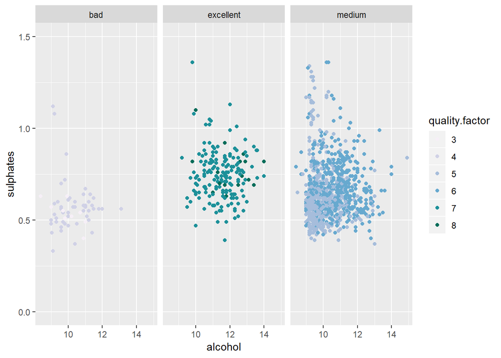

Comparing with sulphates with alcohol content by quality, we see that higher amounts of sulphates combined with higher concentrations of alcohol tends to get higher quality ratings.

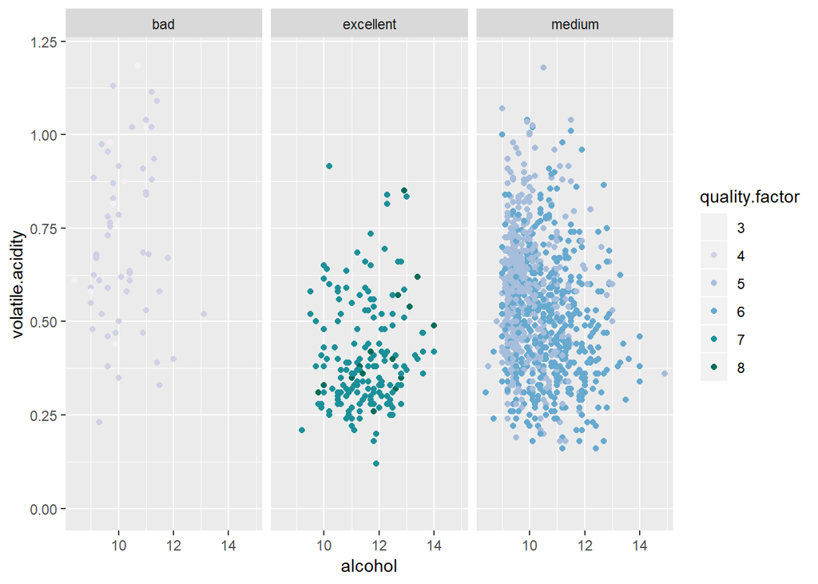

On an average, combination of higher alcohol content and lower volatile acidity yields a better quality red wines. The volatile acidity for medium quality wines have a larger range. However, major concentration of data points are on higher volatile acidity compared to excellent quality wines.

```
##
##  Pearson's product-moment correlation
##
## data:  wine$citric.acid and wine$volatile.acidity
## t = -26.489, df = 1597, p-value < 2.2e-16
## alternative hypothesis: true correlation is not equal to 0
## 95 percent confidence interval:
##  -0.5856550 -0.5174902
## sample estimates:
##        cor
## -0.5524957
```

```
##
##  Pearson's product-moment correlation
##
## data:  wine$citric.acid and wine$quality
## t = 9.2875, df = 1597, p-value < 2.2e-16
## alternative hypothesis: true correlation is not equal to 0
## 95 percent confidence interval:
##  0.1793415 0.2723711
## sample estimates:
##       cor
## 0.2263725
```

```
##
##  Pearson's product-moment correlation
##
## data:  wine$volatile.acidity and wine$quality
## t = -16.954, df = 1597, p-value < 2.2e-16
## alternative hypothesis: true correlation is not equal to 0
## 95 percent confidence interval:
##  -0.4313210 -0.3482032
## sample estimates:
##        cor
## -0.3905578
```

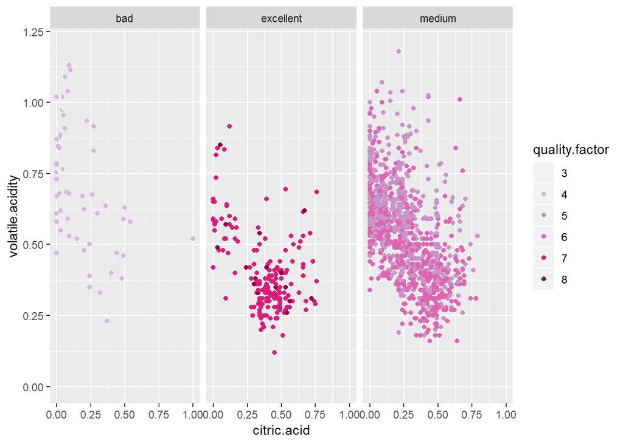

As seen in bivariate plot section, volatile acidity and citric acid have moderate negative correlation, weak positive correlation between quality and citric acid and moderate negative correlation between quality and volatile acidity, we can see these trends in the plot above.

However, for better understanding, let’s visualise it with ratings and best fit linear model line.

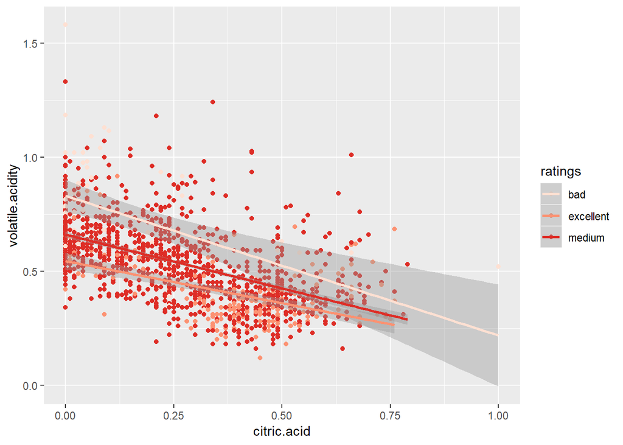

```
##
##  Pearson's product-moment correlation
##
## data:  wine$citric.acid and wine$volatile.acidity
## t = -26.489, df = 1597, p-value < 2.2e-16
## alternative hypothesis: true correlation is not equal to 0
## 95 percent confidence interval:
##  -0.5856550 -0.5174902
## sample estimates:
##        cor
## -0.5524957
```

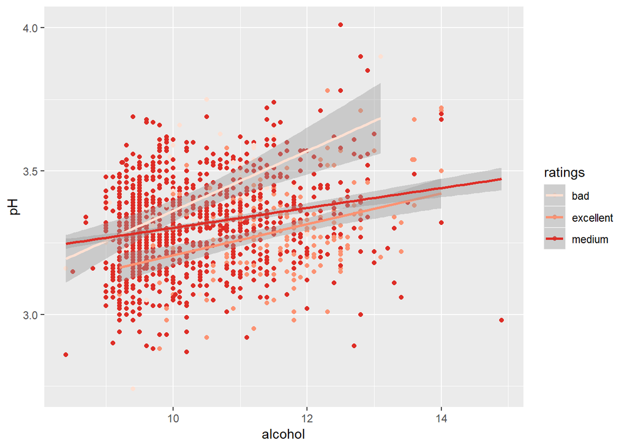

The pH level when plotted against alcohol does not show significant impact on the quality ratings. The difference between excellent and medium rating is very tiny indeed and can not provide a strong evidence. However, increased pH indeed reduces the ratings significantly. It seems that pH levels between 3.0 and 3.75 is where the threshold lies.

```
##
## Calls:
## m1: lm(formula = I(quality) ~ I(alcohol), data = wine)
## m2: lm(formula = I(quality) ~ I(alcohol) + sulphates, data = wine)
## m3: lm(formula = I(quality) ~ I(alcohol) + sulphates + volatile.acidity,
##     data = wine)
## m4: lm(formula = I(quality) ~ I(alcohol) + sulphates + volatile.acidity +
##     fixed.acidity, data = wine)
## m5: lm(formula = I(quality) ~ I(alcohol) + sulphates + volatile.acidity +
##     fixed.acidity + citric.acid, data = wine)
## m6: lm(formula = I(quality) ~ I(alcohol) + sulphates + volatile.acidity +
##     fixed.acidity + citric.acid + density, data = wine)
##
## ========================================================================================================
##                          m1            m2            m3            m4            m5            m6
## --------------------------------------------------------------------------------------------------------
##   (Intercept)           1.875***      1.375***      2.611***      2.313***      2.202***     30.401*
##                        (0.175)       (0.177)       (0.196)       (0.223)       (0.224)      (15.163)
##   I(alcohol)            0.361***      0.346***      0.309***      0.315***      0.320***      0.298***
##                        (0.017)       (0.016)       (0.016)       (0.016)       (0.016)       (0.020)
##   sulphates                           0.994***      0.679***      0.642***      0.701***      0.732***
##                                      (0.102)       (0.101)       (0.101)       (0.103)       (0.104)
##   volatile.acidity                                 -1.221***     -1.155***     -1.343***     -1.302***
##                                                    (0.097)       (0.100)       (0.113)       (0.116)
##   fixed.acidity                                                   0.028**       0.057***      0.077***
##                                                                  (0.010)       (0.013)       (0.017)
##   citric.acid                                                                  -0.469***     -0.460***
##                                                                                (0.137)       (0.137)
##   density                                                                                   -28.268
##                                                                                             (15.198)
## --------------------------------------------------------------------------------------------------------
##   R-squared             0.227         0.270         0.336         0.339         0.344         0.345
##   adj. R-squared        0.226         0.269         0.335         0.337         0.342         0.343
##   sigma                 0.710         0.690         0.659         0.657         0.655         0.655
##   F                   468.267       294.988       268.912       204.457       167.023       139.977
##   p                     0.000         0.000         0.000         0.000         0.000         0.000
##   Log-likelihood    -1721.057     -1675.142     -1599.384     -1595.530     -1589.648     -1587.913
##   Deviance            805.870       760.894       692.105       688.776       683.728       682.245
##   AIC                3448.114      3358.284      3208.768      3203.061      3193.297      3191.826
##   BIC                3464.245      3379.793      3235.654      3235.323      3230.937      3234.843
##   N                  1599          1599          1599          1599          1599          1599
## ========================================================================================================
```

```
##
## Call:
## lm(formula = I(quality) ~ I(alcohol) + sulphates + volatile.acidity +
##     fixed.acidity + citric.acid + density, data = wine)
##
## Residuals:
##      Min       1Q   Median       3Q      Max
## -2.78843 -0.37575 -0.06666  0.46147  2.08190
##
## Coefficients:
##                   Estimate Std. Error t value Pr(>|t|)
## (Intercept)       30.40142   15.16251   2.005 0.045128 *
## I(alcohol)         0.29782    0.01985  15.002  < 2e-16 ***
## sulphates          0.73198    0.10384   7.049 2.68e-12 ***
## volatile.acidity  -1.30154    0.11554 -11.265  < 2e-16 ***
## fixed.acidity      0.07651    0.01678   4.560 5.50e-06 ***
## citric.acid       -0.46018    0.13662  -3.368 0.000774 ***
## density          -28.26812   15.19791  -1.860 0.063070 .
## ---
## Signif. codes:  0 '***' 0.001 '**' 0.01 '*' 0.05 '.' 0.1 ' ' 1
##
## Residual standard error: 0.6546 on 1592 degrees of freedom
## Multiple R-squared:  0.3454, Adjusted R-squared:  0.3429
## F-statistic:   140 on 6 and 1592 DF,  p-value: < 2.2e-16
```

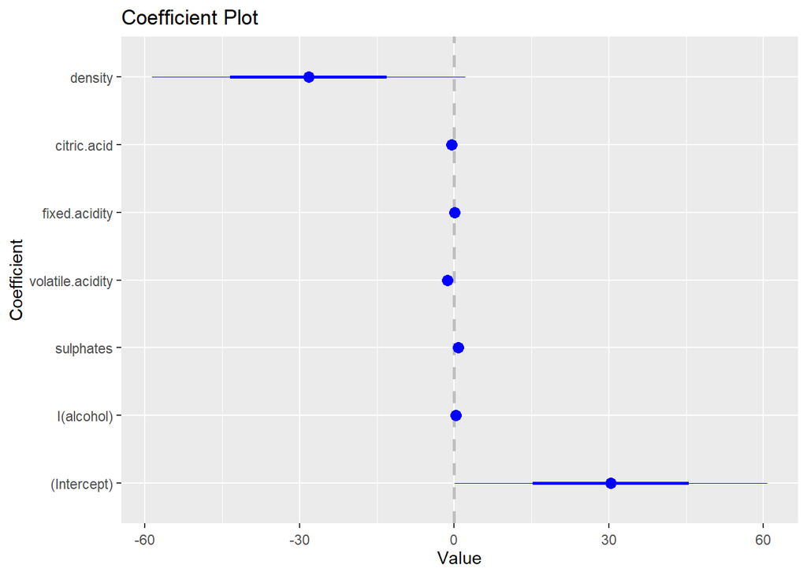

The coefficient plot reflects the effect of the variables on the predictive model. Each dot represents the coefficient fitted by the model. The horizontal bars represents the confidence interval. The thick horizontal bar represents 1-standard error from the coefficient and thinner bar represents 2-standard error. The general rule of thumb is that if 0 is not contained in the standard error bar, then this variable has realistic effect on the response.

```
##     fixed.acidity volatile.acidity citric.acid residual.sugar chlorides
## 425           7.7             0.96         0.2              2     0.047
##     free.sulfur.dioxide total.sulfur.dioxide density   pH sulphates
## 425                  15                   60  0.9955 3.36      0.44
##     alcohol quality quality.factor ratings
## 425    10.9       5              5  medium
```

```
##     fixed.acidity volatile.acidity citric.acid residual.sugar chlorides
## 595           7.9             0.72        0.17            2.6     0.096
##     free.sulfur.dioxide total.sulfur.dioxide density  pH sulphates alcohol
## 595                  20                   38  0.9978 3.4      0.53     9.5
##     quality quality.factor ratings
## 595       5              5  medium
```